# ExMAS(sample)

## Required DEMAND data ("City_requests.csv" exemplifies a data file)

- id
- treq - requested departure time
- origin_x - X-coordinate value of the origin node
- origin_y - Y-coordinate value of the origin node
- destination_x - X-coordinate value of the destination node
- destination_y - Y-coordinate value of the destination node
- origin - origin node (OSM index) - op[tional
- destination - destination node (OSM index) - optional

```python
## This outputs a pandas DataFrame:
import pandas as pd
df = pd.read_csv('City_requests.csv')
df.head()
```

|  | Unnamed: 0 | origin | destination | treq | tarr | ttrav | origin_x | origin_y | destination_x | destination_y | success | n_itineraries | duration | walkDistance | transfers | transitTime | waitingTime | modes |
| --- | --- | --- | --- | --- | --- | --- | --- | --- | --- | --- | --- | --- | --- | --- | --- | --- | --- | --- |
| 0 | 43078 | 46430975 | 46442305 | 2020-10-27 17:42:00 | 1900-01-01 17:47:00 | 0 days 00:05:00 | 4.817485 | 52.380884 | 4.820010 | 52.383424 | True | 2.0 | 359.0 | 437.272639 | 0.0 | 0.0 | 0.0 | [['WALK', 359, 437]] |
| 1 | 43085 | 46427503 | 46560239 | 2020-10-27 17:26:00 | 1900-01-01 18:01:00 | 0 days 00:35:00 | 4.834819 | 52.380153 | 4.913162 | 52.418185 | True | 3.0 | 2971.0 | 2302.549714 | 0.0 | 1109.0 | 2.0 | [['WALK', 992, 1199], ['BUS', 1109, 6503], ['W... |
| 2 | 43087 | 1715224324 | 46427992 | 2020-10-27 17:35:00 | 1900-01-01 17:40:00 | 0 days 00:05:00 | 4.820647 | 52.373804 | 4.828323 | 52.380275 | True | 3.0 | 690.0 | 473.136173 | 0.0 | 300.0 | 2.0 | [['WALK', 261, 317], ['TRAM', 300, 1458], ['WA... |
| 3 | 43099 | 3307343586 | 46176460 | 2020-10-27 17:58:00 | 1900-01-01 18:22:00 | 0 days 00:24:00 | 4.860901 | 52.350759 | 4.867612 | 52.324314 | True | 3.0 | 1391.0 | 782.054684 | 1.0 | 680.0 | 71.0 | [['WALK', 313, 376], ['BUS', 398, 1983], ['WAL... |
| 4 | 43105 | 46306915 | 46445707 | 2020-10-27 17:46:00 | 1900-01-01 18:01:00 | 0 days 00:15:00 | 4.820379 | 52.353578 | 4.825973 | 52.384198 | True | 3.0 | 1868.0 | 1162.185677 | 1.0 | 866.0 | 57.0 | [['WALK', 478, 589], ['BUS', 600, 3619], ['WAL... |

## NETWORK

```python
# pip install --user notebook
!pip install ExMAS
```

```python
import os
cwd = os.getcwd()
```

```python
# os.chdir(os.path.join(cwd,'../..'))  # main package directory
import ExMAS
import ExMAS.main
import ExMAS.utils
import pprint
```

## Import network and compute skim for a city

Here we download city graph, compute the skims and save to graphml and csvs for future use in ExMAS

It:

- loads data for params.city
- computes the skim
- saves the files into params.paths.skim and params.paths.G

```python
params = ExMAS.utils.get_config('default.json')
```

```python
# current city
params.city
```

```
'Delft, Netherlands'
```

```python
params.city = 'Nootdorp, Netherlands'
params = ExMAS.utils.make_paths(params) # update file paths
```

```python
from ExMAS.utils import inData as inData
```

```python
inData = ExMAS.utils.download_G(inData, params) # download the graph and compute the skim
```

```python
inData.skim # the distance between the each pair of nodes based on dijkstra
```

|  | 44964616 | 306568278 | 306568311 | 306568310 | 306568277 | 306568309 | 661170806 | 513920275 | 513898290 | 44971443 | ... | 45028719 | 45026903 | 45014331 | 45028271 | 1454319183 | 411012808 | 45017594 | 45019266 | 44983951 | 3867423185 |
| --- | --- | --- | --- | --- | --- | --- | --- | --- | --- | --- | --- | --- | --- | --- | --- | --- | --- | --- | --- | --- | --- |
| 44964616 | 0 | 20 | 41 | 48 | 64 | 74 | 74 | 82 | 86 | 204 | ... | 2984 | 3014 | 3048 | 3082 | 3114 | 3189 | 3484 | 3550 | 4363 | 100000 |
| 44969118 | 1957 | 1945 | 1966 | 1973 | 1989 | 1928 | 1999 | 1936 | 1899 | 2128 | ... | 3854 | 3883 | 3918 | 3952 | 3984 | 1203 | 4353 | 4419 | 5233 | 100000 |
| 44969502 | 2169 | 2157 | 2178 | 2184 | 2201 | 2139 | 2211 | 2147 | 2111 | 2340 | ... | 4065 | 4095 | 4129 | 4163 | 4196 | 1315 | 4565 | 4631 | 5444 | 100000 |
| 44969511 | 239 | 227 | 248 | 255 | 271 | 210 | 281 | 218 | 181 | 410 | ... | 2914 | 2943 | 2977 | 3012 | 3044 | 2921 | 3413 | 3479 | 4293 | 100000 |
| 44970065 | 1803 | 1791 | 1812 | 1819 | 1835 | 1774 | 1845 | 1782 | 1745 | 1974 | ... | 3700 | 3730 | 3764 | 3798 | 3830 | 1357 | 4200 | 4266 | 5079 | 100000 |
| ... | ... | ... | ... | ... | ... | ... | ... | ... | ... | ... | ... | ... | ... | ... | ... | ... | ... | ... | ... | ... | ... |
| 10301476143 | 339 | 360 | 381 | 388 | 404 | 413 | 414 | 422 | 426 | 543 | ... | 3324 | 3354 | 3388 | 3422 | 3454 | 3529 | 3824 | 3890 | 4703 | 100000 |
| 10301476146 | 311 | 332 | 353 | 360 | 376 | 385 | 386 | 393 | 398 | 515 | ... | 3295 | 3325 | 3359 | 3394 | 3426 | 3501 | 3795 | 3861 | 4675 | 100000 |
| 10639446904 | 3312 | 3300 | 3321 | 3257 | 3274 | 3283 | 3220 | 3291 | 3295 | 3091 | ... | 817 | 896 | 2245 | 2279 | 2311 | 5526 | 2681 | 2747 | 3560 | 100000 |
| 10647334160 | 1855 | 1842 | 1863 | 1870 | 1886 | 1825 | 1896 | 1833 | 1797 | 2026 | ... | 3728 | 3758 | 3792 | 3826 | 3858 | 2526 | 4228 | 4294 | 5107 | 100000 |
| 10647334166 | 1907 | 1895 | 1916 | 1923 | 1939 | 1878 | 1949 | 1886 | 1849 | 2078 | ... | 3780 | 3810 | 3844 | 3878 | 3911 | 2578 | 4280 | 4346 | 5159 | 100000 |

579 rows × 579 columns

```python
ExMAS.utils.save_G(inData, params) # save it to params.paths.G
```

## Some osmnx tutorial

we import graphs with osmnx

for different cities, change the string

### 1. Import driveable network for Nootdorp

```python
#small imports
import sys
import random
import time
import pprint
import matplotlib
%matplotlib inline
matplotlib.rcParams['figure.figsize'] = [16, 16]
```

```python
#big imports
import osmnx as ox #OSM download and parse
import pandas as pd
import networkx as nx #graphs
```

### 2. Plot it

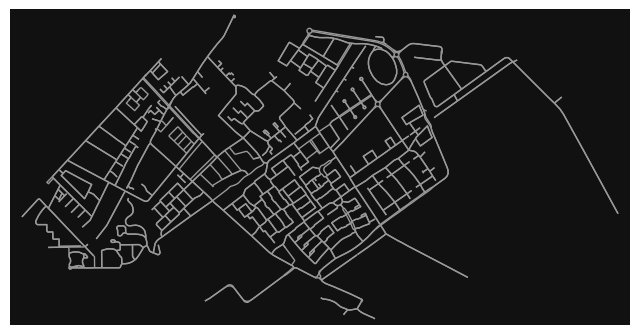

```python
fig, ax = ox.plot_graph(inData.G, node_size=0)
# G = ox.load_graphml('ExMAS/data/graphs/Nootdorp.graphml')
# fig, ax = ox.plot_graph(G)
```

- Network stats

```python
pprint.pprint(ox.basic_stats(inData.G))
```

```
{'circuity_avg': 1.1114121339756264,
 'edge_length_avg': 88.48482420749275,
 'edge_length_total': 122816.93599999994,
 'intersection_count': 468,
 'k_avg': 4.79447322970639,
 'm': 1388,
 'n': 579,
 'self_loop_proportion': 0.014175257731958763,
 'street_length_avg': 86.73151932989697,
 'street_length_total': 67303.65900000004,
 'street_segment_count': 776,
 'streets_per_node_avg': 2.680483592400691,
 'streets_per_node_counts': {0: 0, 1: 111, 2: 16, 3: 401, 4: 49, 5: 2},
 'streets_per_node_proportions': {0: 0.0,
                                  1: 0.19170984455958548,
                                  2: 0.027633851468048358,
                                  3: 0.6925734024179621,
                                  4: 0.0846286701208981,
                                  5: 0.0034542314335060447}}
```

### 3. Graph data

```python
G = inData.G
# G.edges
node_list = list(G.nodes)
node_ide = random.choice(node_list)
G.nodes[node_ide]
```

```
{'y': 52.0499457, 'x': 4.4124493, 'street_count': 3}
```

### 4. Graph searches

```python
node_list = list(G.nodes)
o = random.choice(node_list)
d = random.choice(node_list)
```

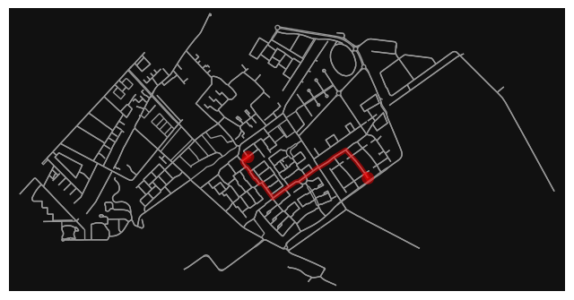

```
Shorthest path from node 514022771 to node 44995663 with distance: 1388.104 m
```

```python
# find the route between these nodes then plot it
route = nx.shortest_path(G, o, d, weight='length')
fig, ax = ox.plot_graph_route(G, route, node_size=0)

print("Shorthest path from node {} to node {} with distance: {} m".format(o,d,nx.shortest_path_length(G, o, d, weight='length')))
```

## SYNTHETIC DEMAND GENERATION

We generate `params.nP` trip requests (`inData.requests`).

Requests are defined through:

- origin (node of `inData.G` graph)
- destinations (node of `inData.G` graph)
- treq (requested departure time)
- origins are drawn from random distribution `math.exp(_params.demand_structure.origins_dispertion*x))`, where `x` is distance from `inData.networkStats.center` (in meters)
- destinations similarly, yet with `_params.demand_structure.destinations_dispertion`
- treq is drawn from uniform distribution between $[t0-T/2,t0+T/2]$, where $t0$ is `params.t0` and $T$ is `params.simTime' (optionally normal distribution may be applied, but it seems impractical)

We use function `generate_demand` from `dataStructures.ipynb` to generate the demand

We visualize the demand with `plot_demand` from `utils/plot_utils.ipynb`

- `dist` of requerst is given im meters
- `ttrav` of request is either calculated as dist divided by `params.avg_speed` (in [m/s]) or estimated using real-time data (in general travel times shall be estimarted within current study using givwen assumption on trip time and speed).

```python
params.nP #number of passengers
```

```
200
```

```python
params.city
```

```
'Nootdorp, Netherlands'
```

```python
params.simTime # demand simulation time [hours]
```

```
1
```

```python
params.demand_structure.destinations_dispertion # controls how destinations are dispersed from center (see negative exponenetial decay funct
```

```
-0.001
```

```python
params.demand_structure.origins_dispertion # controls how origins are dispersed from center
```

```
-0.0003
```

```python
pprint.pprint(params.demand_structure)
```

```
{'destinations_dispertion': -0.001,
 'origins_dispertion': -0.0003,
 'temporal_dispertion': 0.3,
 'temporal_distribution': 'uniform'}
```

```python
inData = ExMAS.utils.load_G(inData, params, stats=True)  # download the graph
```

```python
inData = ExMAS.utils.generate_demand(inData, params) #generate trip requests
```

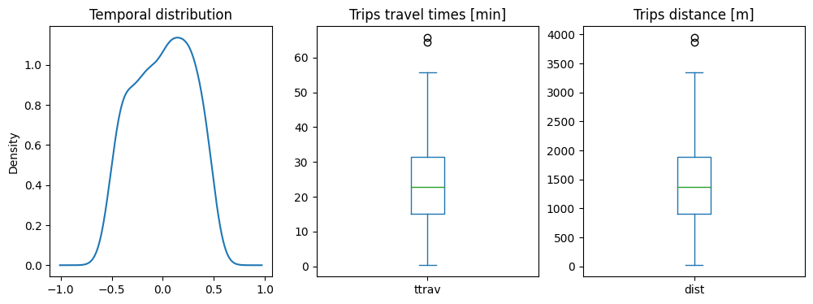

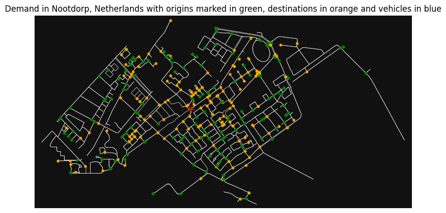

```python
ExMAS.utils.plot_demand(inData, params)
```

## ExMAS

```python
# params = ExMAS.utils.get_config('ExMAS-plotting/InputData(ExMAS)/default.json') # load the default
# params.nP = 3000
# params.simTime = 4
```

```python
inData = ExMAS.utils.generate_demand(inData, params) #generate trip requests
```

## run

```python
inData = ExMAS.main(inData, params)
```

```
27-11-23 11:35:23-INFO-Initializing pairwise trip shareability between 200 and 200 trips.
27-11-23 11:35:23-INFO-creating combinations
27-11-23 11:35:24-INFO-39800	 nR*(nR-1)
27-11-23 11:35:24-INFO-Reduction of feasible pairs by 99.75%
27-11-23 11:35:24-INFO-Degree 2 	Completed
27-11-23 11:35:24-INFO-trips to extend at degree 2 : 308
27-11-23 11:35:24-INFO-At degree 2 feasible extensions found out of 10 searched
27-11-23 11:35:24-INFO-Degree 3 	Completed
27-11-23 11:35:24-INFO-trips to extend at degree 3 : 10
27-11-23 11:35:24-INFO-At degree 3 feasible extensions found out of 0 searched
27-11-23 11:35:24-INFO-Degree 4 	Completed
27-11-23 11:35:24-INFO-No more trips to exted at degree 4
27-11-23 11:35:24-INFO-Matching 200 trips to 518 rides in order to minimize u_veh
27-11-23 11:35:25-INFO-Problem solution: Optimal.
Total costs for single trips:         36,876
reduced by matching to:               32,479
27-11-23 11:35:25-INFO-Calculations  completed
27-11-23 11:35:25-INFO-DotMap(VehHourTrav=31909, VehHourTrav_ns=36876, PassHourTrav=39745, PassHourTrav_ns=36876, PassUtility=548.294025, PassUtility_ns=572.6355000000001, mean_lambda=0.2145715401132149, revenue_s=38719.799999999996, revenue_ns=55314.0, Fare_Discount=-0.3000000000000001, nR=200, SIN…
```

## results:

KPIs

```python
KPIs = inData.sblts.res.to_frame()[:23]
KPIs['description']  = ExMAS.utils.KPIs_descriptions
KPIs.columns = ['KPI', 'description']
KPIs
```

|  | KPI | description |
| --- | --- | --- |
| VehHourTrav | 31909 | total travel time of vehicles (with travellers... |
| VehHourTrav_ns | 36876 | as above yet in non-shared scenarion |
| PassHourTrav | 39745 | total travel time of passengers |
| PassHourTrav_ns | 36876 | as above yet in non-shared scenarion |
| PassUtility | 548.294025 | total (dis)utility of passengers |
| PassUtility_ns | 572.6355 | as above yet in non-shared scenarion |
| mean_lambda | 0.214572 | mean vehicle cost reduction (lambda) over shar... |
| revenue_s | 38719.8 | total fares paid by travellers sharing |
| revenue_ns | 55314.0 | as above yet in non-shared scenarion |
| Fare_Discount | -0.3 | relative revenue reduction |
| nR | 200 | number of trips |
| SINGLE | 112 | number of single rides in the solution |
| PAIRS | 38 | 2nd degree rides in the solution |
| TRIPLES | 4 | 3rd degree rides in the solution |
| QUADRIPLES | 0 | 4th degree rides in the solution |
| QUINTETS | 0 | 5th degree rides in the solution |
| PLUS5 | 0 | rides of degree greater than 5 in the solution |
| shared_ratio | 0.44 | what portion of rides were shared |
| fleet_size_nonshared | 15.0 | proxy for the fleet size (lower bound) |
| fleet_size_shared | 13.0 | as above yet in non-shared scenarion |
| lambda_shared | 0.214572 | maximal discount to be offered while profitable |
| _typ | {'_typ': {}} | sys |
| ndim | {'_typ': {}} | sys |

RIDES

```python
inData.sblts.rides.sample(5)
```

|  | indexes | u_pax | u_veh | kind | u_paxes | times | indexes_orig | indexes_dest | degree | index | lambda_r | PassHourTrav_ns | row | selected |
| --- | --- | --- | --- | --- | --- | --- | --- | --- | --- | --- | --- | --- | --- | --- |
| 197 | [197] | 2.71550 | 175 | 1 | [2.7155000000000005] | [3520, 175] | [197] | [197] | 1.0 | 197 | 0.30000 | 175 | [0.0, 0.0, 0.0, 0.0, 0.0, 0.0, 0.0, 0.0, 0.0, ... | 1 |
| 270 | [16, 39] | 9.43285 | 674 | 20 | [7.706299999999999, 1.7265499999999998] | [288.0, 528, 116, 15] | [16, 39] | [16, 39] | 2.0 | 270 | 0.01173 | 682 | [0.0, 0.0, 0.0, 0.0, 0.0, 0.0, 0.0, 0.0, 0.0, ... | 0 |
| 480 | [65, 71] | 6.21915 | 458 | 21 | [5.109475, 1.1096749999999997] | [1265.5, 186, 73, 184] | [65, 71] | [71, 65] | 2.0 | 480 | -0.10628 | 414 | [0.0, 0.0, 0.0, 0.0, 0.0, 0.0, 0.0, 0.0, 0.0, ... | 0 |
| 22 | [22] | 4.30100 | 277 | 1 | [4.301] | [451, 277] | [22] | [22] | 1.0 | 22 | 0.30000 | 277 | [0.0, 0.0, 0.0, 0.0, 0.0, 0.0, 0.0, 0.0, 0.0, ... | 0 |
| 126 | [126] | 3.45650 | 223 | 1 | [3.4565] | [2252, 223] | [126] | [126] | 1.0 | 126 | 0.30000 | 223 | [0.0, 0.0, 0.0, 0.0, 0.0, 0.0, 0.0, 0.0, 0.0, ... | 0 |

SCEDULE

```python
inData.sblts.schedule.sample(5)
```

|  | indexes | u_pax | u_veh | kind | u_paxes | times | indexes_orig | indexes_dest | degree | index | lambda_r | PassHourTrav_ns | row | selected |
| --- | --- | --- | --- | --- | --- | --- | --- | --- | --- | --- | --- | --- | --- | --- |
| 85 | [85] | 1.08000 | 69 | 1 | [1.08] | [1668, 69] | [85] | [85] | 1 | 85 | 0.300000 | 69 | [0.0, 0.0, 0.0, 0.0, 0.0, 0.0, 0.0, 0.0, 0.0, ... | 1 |
| 31 | [31] | 1.52050 | 98 | 1 | [1.5205] | [623, 98] | [31] | [31] | 1 | 31 | 0.300000 | 98 | [0.0, 0.0, 0.0, 0.0, 0.0, 0.0, 0.0, 0.0, 0.0, ... | 1 |
| 148 | [148] | 0.12850 | 8 | 1 | [0.1285] | [2655, 8] | [148] | [148] | 1 | 148 | 0.300000 | 8 | [0.0, 0.0, 0.0, 0.0, 0.0, 0.0, 0.0, 0.0, 0.0, ... | 1 |
| 117 | [117] | 2.65050 | 171 | 1 | [2.6505] | [2098, 171] | [117] | [117] | 1 | 117 | 0.300000 | 171 | [0.0, 0.0, 0.0, 0.0, 0.0, 0.0, 0.0, 0.0, 0.0, ... | 1 |
| 330 | [48, 53] | 6.28425 | 389 | 20 | [2.9246, 3.3596499999999994] | [950.0, 108, 145, 121] | [48, 53] | [48, 53] | 2 | 330 | 0.099537 | 432 | [0.0, 0.0, 0.0, 0.0, 0.0, 0.0, 0.0, 0.0, 0.0, ... | 1 |

REQUESTS

```python
inData.sblts.requests.sample(5)
```

|  | index | origin | destination | treq | tdep | ttrav | tarr | tdrop | dist | pax_id | VoT | delta | u | u_PT | ride_id | ttrav_sh | u_sh | kind | position |
| --- | --- | --- | --- | --- | --- | --- | --- | --- | --- | --- | --- | --- | --- | --- | --- | --- | --- | --- | --- |
| 17 | 19 | 513920275 | 45033214 | 290 | NaN | 306 | 2023-11-27 15:16:00 | NaN | 2450 | 19 | 0.0035 | 171.692308 | 4.7460 | 999999 | 17 | 306 | 4.746000 | 1 | 0 |
| 168 | 119 | 1402795348 | 45006066 | 2961 | NaN | 156 | 2023-11-27 15:40:36 | NaN | 1255 | 119 | 0.0035 | 88.120879 | 2.4285 | 999999 | 434 | 156 | 2.066225 | 21 | 1 |
| 75 | 101 | 45029511 | 2273226090 | 1483 | NaN | 57 | 2023-11-27 15:02:45 | NaN | 462 | 101 | 0.0035 | 32.538462 | 0.8925 | 999999 | 75 | 57 | 0.892500 | 1 | 0 |
| 99 | 143 | 44989733 | 44977048 | 1871 | NaN | 101 | 2023-11-27 15:15:04 | NaN | 813 | 143 | 0.0035 | 57.098901 | 1.5730 | 999999 | 99 | 101 | 1.573000 | 1 | 0 |
| 127 | 198 | 44982387 | 515749669 | 2289 | NaN | 107 | 2023-11-27 15:22:47 | NaN | 858 | 198 | 0.0035 | 60.164835 | 1.6615 | 999999 | 127 | 107 | 1.661500 | 1 | 0 |